# Data Analytics for Business

## Session 6-7, Classification

T. Evgeniou  
INSEAD

## Example Applications

- Which molecules are most likely to succeed for the drug?
- Whose DNA is most likely to indicate future health problems of a particular type?
- Who are the most likely clients/companies/countries to default on their debt?
- Who are most likely to click on an ad?
- To whom should we offer a particular promotion?
- How are satisfied customers different from dissatisfied customers in terms of their demographics and attitudes towards your products’ characteristics?
- Which transaction is most likely a fraud?
- Which applicants are most likely to fit in our organization and succeed?
- Which investments are most likely to succeed?

## What is common to these problems?

1. There is a dependent variable which is categorical e.g. success vs failure (fit vs. non-fit; fraud vs. non-fraud, response vs. non-response, etc.)
2. There are some independent variables which we can use to explain membership in the different categories

## Example: Boats Purchase Drivers

Who would be the most likely customers to purchase a boat in the future or to recommend their brand?

What would be the **key drivers** that affect people's decision to purchase or recommend?

## Various Methods

- Logistic regression
- Classification trees
- Boosted Trees
- Nearest Neighbors
- Neural Networks
- Bayesian methods
- Support Vector Machines
- Deep learning methods
- others...

## Classification: A Process

1. Create an estimation and two validation samples in a balanced way
2. Setup the dependent variable (what is a success?)
3. Assess and select the independent variables
4. Estimate model (many methods, we consider only 2 here)
5. Assess performance on first validation data, repeat steps 2-5 as necessary
6. Assess performance on second validation data once

## Data Splits: Example Split

Estimation Data: 80% of the data

Validation Data: 10% of the data

Test Data: 10% of the data

## Example: Some Data

|  | Variables | Q16_1_Is.a.brand.that.has.been.around.for.a.long.time | Q16_2_Has.best.in.class.customer.service | Q16_3_Has.a.strong.dealer.network | Q16_4_Is.a.leader.in.cutting.edge.technology | Q16_5_Is.a.leader.in.safety | Q16_6_Is.known.for.its.innovative.products | Q16_7_Is.a.brand.for.people.who.are.serious.about.boating | Q16_8_Is.a.good.brand.for.people.that.are.new.to.boating | Q16_9_Is.a.brand.I.see.in.the.water.all.the.time | Q16_10_Offers.boats.that.provide.a.fast.and.powerful.boating.experience | Q16_11_Offers.the.best.boats.for.socializing | Q16_12_Offers.the.best.boats.for.water.sports..e.g...tubing..ski..wakeboard. | Q16_13_Offers.boats.with.superior.interior.style | Q16_14_Offers.boats.with.superior.exterior.style | Q16_15_Offers.boats.that.stand.out.from.the.crowd | Q16_16_Offers.boats.that.look.cool | Q16_17_Offers.boats.that.can.handle.rough.weather.or.choppy.water | Q16_18_Offers.boats.that.can.handle.frequent.and.heavy.usage | Q16_19_Offers.a.wide.breadth.of.product.offerings.and.accessories | Q16_20_Offers.boats.that.I.can.move.around.safely | Q16_21_Offers.boats.that.are.easy.to.maintain.and.or.repair | Q16_22_Offers.boats.that.are.easy.to.use | Q16_23_Offers.boats.that.are.easy.to.clean.up | Q16_24_Has.low.prices | Q16_25_Is.a.brand.that.gives.me.peace.of.mind | Q16_26_Makes.me.feel.I.made.a.smart.decision | Q16_27_Is.a.brand.that.impresses.others |
| --- | --- | --- | --- | --- | --- | --- | --- | --- | --- | --- | --- | --- | --- | --- | --- | --- | --- | --- | --- | --- | --- | --- | --- | --- | --- | --- | --- | --- |
| 1 | 1 | 3.0 | 4.0 | 4.0 | 3.0 | 4.0 | 4.0 | 4.0 | 4.0 | 4.0 | 4.0 | 4.0 | 4.0 | 4.0 | 4.0 | 4.0 | 4.0 | 4.0 | 4.0 | 4.0 | 4.0 | 4.0 | 4.0 | 4.0 | 5.0 | 4.0 | 4.0 | 4.0 |
| 2 | 2 | 3.0 | 3.0 | 4.0 | 3.0 | 3.0 | 3.0 | 4.0 | 4.0 | 5.0 | 4.0 | 4.0 | 3.0 | 4.0 | 4.0 | 4.0 | 4.0 | 4.0 | 4.0 | 3.0 | 4.0 | 3.0 | 3.0 | 4.0 | 3.0 | 3.0 | 3.0 | 3.0 |
| 3 | 3 | 4.0 | 4.0 | 3.0 | 4.0 | 3.0 | 5.0 | 5.0 | 4.0 | 5.0 | 5.0 | 4.0 | 3.0 | 4.0 | 4.0 | 5.0 | 4.0 | 5.0 | 4.0 | 5.0 | 5.0 | 3.0 | 3.0 | 5.0 | 2.0 | 4.0 | 3.0 | 5.0 |
| 4 | 4 | 4.0 | 4.0 | 4.0 | 4.0 | 5.0 | 4.0 | 5.0 | 4.0 | 5.0 | 5.0 | 4.0 | 4.0 | 5.0 | 4.0 | 5.0 | 4.0 | 5.0 | 5.0 | 4.0 | 4.0 | 4.0 | 4.0 | 4.0 | 2.0 | 5.0 | 5.0 | 4.0 |
| 5 | 5 | 5.0 | 5.0 | 5.0 | 5.0 | 5.0 | 4.0 | 1.0 | 5.0 | 5.0 | 4.0 | 5.0 | 4.0 | 4.0 | 4.0 | 4.0 | 4.0 | 5.0 | 4.0 | 4.0 | 4.0 | 4.0 | 5.0 | 5.0 | 3.0 | 4.0 | 5.0 | 4.0 |
| 6 | 6 | 4.0 | 4.0 | 4.0 | 4.0 | 4.0 | 4.0 | 4.0 | 4.0 | 4.0 | 4.0 | 4.0 | 4.0 | 4.0 | 4.0 | 4.0 | 4.0 | 4.0 | 4.0 | 4.0 | 4.0 | 4.0 | 4.0 | 4.0 | 3.0 | 4.0 | 4.0 | 4.0 |
| 7 | 7 | 4.0 | 4.0 | 3.0 | 3.0 | 3.0 | 3.0 | 4.0 | 4.0 | 3.0 | 3.0 | 4.0 | 4.0 | 3.0 | 4.0 | 3.0 | 3.0 | 3.0 | 3.0 | 3.0 | 3.0 | 3.0 | 3.0 | 3.0 | 3.0 | 4.0 | 3.0 | 3.0 |
| 8 | 8 | 2.0 | 3.0 | 4.0 | 4.0 | 4.0 | 4.0 | 3.0 | 4.0 | 4.0 | 5.0 | 2.0 | 5.0 | 3.0 | 4.0 | 5.0 | 4.0 | 5.0 | 5.0 | 5.0 | 4.0 | 4.0 | 4.0 | 4.0 | 4.0 | 3.0 | 4.0 | 3.0 |
| 9 | 9 | 4.0 | 3.0 | 3.0 | 3.0 | 3.0 | 3.0 | 3.0 | 4.0 | 4.0 | 3.0 | 3.0 | 3.0 | 3.0 | 4.0 | 4.0 | 4.0 | 3.0 | 4.0 | 3.0 | 4.0 | 4.0 | 4.0 | 4.0 | 3.0 | 3.0 | 3.0 | 3.0 |
| 10 | 10 | 4.0 | 2.0 | 4.0 | 4.0 | 4.0 | 4.0 | 5.0 | 3.0 | 3.0 | 5.0 | 5.0 | 3.0 | 4.0 | 3.0 | 4.0 | 5.0 | 2.0 | 3.0 | 2.0 | 2.0 | 1.0 | 4.0 | 4.0 | 4.0 | 5.0 | 5.0 | 3.0 |
| 11 | 11 | 5.0 | 5.0 | 5.0 | 5.0 | 5.0 | 5.0 | 5.0 | 5.0 | 5.0 | 5.0 | 5.0 | 5.0 | 5.0 | 5.0 | 5.0 | 5.0 | 5.0 | 5.0 | 5.0 | 5.0 | 5.0 | 5.0 | 5.0 | 5.0 | 3.0 | 5.0 | 5.0 |
| 12 | 12 | 4.0 | 5.0 | 4.0 | 5.0 | 4.0 | 5.0 | 3.0 | 4.0 | 5.0 | 5.0 | 4.0 | 4.0 | 4.0 | 4.0 | 5.0 | 5.0 | 5.0 | 4.0 | 4.0 | 5.0 | 4.0 | 5.0 | 4.0 | 5.0 | 4.0 | 4.0 | 4.0 |
| 13 | 13 | 4.0 | 5.0 | 4.0 | 4.0 | 4.0 | 5.0 | 4.0 | 4.0 | 5.0 | 4.0 | 4.0 | 4.0 | 4.0 | 3.0 | 4.0 | 3.0 | 3.0 | 3.0 | 4.0 | 3.0 | 3.0 | 4.0 | 3.0 | 3.0 | 4.0 | 3.0 | 4.0 |
| 14 | 14 | 2.0 | 4.0 | 4.0 | 4.0 | 3.0 | 4.0 | 4.0 | 4.0 | 4.0 | 4.0 | 4.0 | 3.0 | 4.0 | 4.0 | 4.0 | 3.0 | 4.0 | 4.0 | 4.0 | 4.0 | 4.0 | 4.0 | 4.0 | 4.0 | 3.0 | 4.0 | 4.0 |
| 15 | 15 | 5.0 | 4.0 | 4.0 | 5.0 | 5.0 | 5.0 | 5.0 | 5.0 | 5.0 | 2.0 | 5.0 | 5.0 | 5.0 | 4.0 | 5.0 | 5.0 | 5.0 | 5.0 | 4.0 | 5.0 | 4.0 | 5.0 | 4.0 | 4.0 | 4.0 | 5.0 | 5.0 |
| 16 | 16 | 4.0 | 4.0 | 4.0 | 4.0 | 4.0 | 3.0 | 4.0 | 4.0 | 3.0 | 5.0 | 5.0 | 4.0 | 4.0 | 4.0 | 5.0 | 4.0 | 4.0 | 4.0 | 4.0 | 4.0 | 4.0 | 5.0 | 5.0 | 5.0 | 4.0 | 5.0 | 5.0 |
| 17 | 17 | 5.0 | 4.0 | 4.0 | 4.0 | 4.0 | 5.0 | 3.0 | 5.0 | 3.0 | 4.0 | 4.0 | 3.0 | 3.0 | 3.0 | 5.0 | 3.0 | 5.0 | 5.0 | 4.0 | 4.0 | 5.0 | 3.0 | 5.0 | 3.0 | 4.0 | 5.0 | 5.0 |
| 18 | 18 | 4.0 | 5.0 | 5.0 | 4.0 | 5.0 | 5.0 | 5.0 | 5.0 | 4.0 | 4.0 | 4.0 | 2.0 | 5.0 | 3.0 | 4.0 | 5.0 | 4.0 | 5.0 | 5.0 | 4.0 | 5.0 | 4.0 | 5.0 | 4.0 | 5.0 | 4.0 | 4.0 |
| 19 | 19 | 4.0 | 4.0 | 5.0 | 4.0 | 5.0 | 5.0 | 5.0 | 4.0 | 5.0 | 4.0 | 5.0 | 4.0 | 4.0 | 4.0 | 5.0 | 5.0 | 4.0 | 5.0 | 5.0 | 4.0 | 4.0 | 4.0 | 4.0 | 4.0 | 5.0 | 4.0 | 4.0 |
| 20 | 20 | 4.0 | 5.0 | 4.0 | 3.0 | 4.0 | 4.0 | 3.0 | 5.0 | 4.0 | 5.0 | 3.0 | 5.0 | 5.0 | 3.0 | 5.0 | 3.0 | 5.0 | 5.0 | 4.0 | 5.0 | 4.0 | 5.0 | 5.0 | 4.0 | 4.0 | 3.0 | 4.0 |
| 21 | 21 | 3.0 | 4.0 | 4.0 | 4.0 | 4.0 | 4.0 | 4.0 | 4.0 | 4.0 | 4.0 | 4.0 | 4.0 | 4.0 | 4.0 | 4.0 | 4.0 | 4.0 | 4.0 | 4.0 | 4.0 | 4.0 | 4.0 | 4.0 | 3.0 | 3.0 | 4.0 | 4.0 |
| 22 | 22 | 5.0 | 4.0 | 4.0 | 4.0 | 4.0 | 4.0 | 4.0 | 5.0 | 3.0 | 4.0 | 5.0 | 2.0 | 5.0 | 3.0 | 3.0 | 3.0 | 4.0 | 4.0 | 4.0 | 5.0 | 4.0 | 5.0 | 4.0 | 3.0 | 4.0 | 3.0 | 3.0 |
| 23 | 23 | 3.0 | 3.0 | 4.0 | 3.0 | 3.0 | 4.0 | 3.0 | 3.0 | 3.0 | 4.0 | 3.0 | 3.0 | 3.0 | 4.0 | 4.0 | 4.0 | 3.0 | 3.0 | 3.0 | 3.0 | 3.0 | 4.0 | 3.0 | 4.0 | 4.0 | 3.0 | 3.0 |
| 24 | 24 | 4.0 | 3.0 | 5.0 | 4.0 | 5.0 | 5.0 | 5.0 | 5.0 | 4.0 | 5.0 | 3.0 | 5.0 | 5.0 | 5.0 | 5.0 | 4.0 | 5.0 | 4.0 | 4.0 | 5.0 | 5.0 | 5.0 | 5.0 | 5.0 | 5.0 | 5.0 | 5.0 |
| 25 | 25 | 5.0 | 5.0 | 4.0 | 5.0 | 5.0 | 5.0 | 5.0 | 5.0 | 5.0 | 5.0 | 5.0 | 5.0 | 5.0 | 5.0 | 5.0 | 5.0 | 4.0 | 5.0 | 5.0 | 5.0 | 5.0 | 5.0 | 5.0 | 5.0 | 5.0 | 5.0 | 5.0 |
| 26 | 26 | 2.0 | 5.0 | 5.0 | 5.0 | 5.0 | 5.0 | 5.0 | 5.0 | 5.0 | 5.0 | 3.0 | 4.0 | 5.0 | 5.0 | 5.0 | 3.0 | 4.0 | 5.0 | 5.0 | 5.0 | 5.0 | 3.0 | 5.0 | 5.0 | 5.0 | 5.0 | 5.0 |
| 27 | 27 | 3.0 | 3.0 | 4.0 | 3.0 | 4.0 | 4.0 | 3.0 | 3.0 | 3.0 | 4.0 | 3.0 | 3.0 | 4.0 | 4.0 | 4.0 | 4.0 | 4.0 | 4.0 | 4.0 | 3.0 | 4.0 | 4.0 | 4.0 | 3.0 | 3.0 | 4.0 | 4.0 |
| 28 | 28 | 5.0 | 4.0 | 5.0 | 5.0 | 5.0 | 5.0 | 5.0 | 5.0 | 5.0 | 5.0 | 3.0 | 5.0 | 4.0 | 5.0 | 5.0 | 5.0 | 5.0 | 5.0 | 5.0 | 5.0 | 5.0 | 5.0 | 5.0 | 4.0 | 5.0 | 5.0 | 3.0 |
| 29 | 29 | 5.0 | 3.0 | 4.0 | 4.0 | 4.0 | 4.0 | 5.0 | 3.0 | 5.0 | 5.0 | 3.0 | 3.0 | 4.0 | 4.0 | 5.0 | 5.0 | 5.0 | 5.0 | 4.0 | 4.0 | 4.0 | 4.0 | 4.0 | 2.0 | 5.0 | 5.0 | 5.0 |
| 30 | 30 | 3.0 | 3.0 | 4.0 | 4.0 | 4.0 | 4.0 | 5.0 | 5.0 | 4.0 | 3.0 | 4.0 | 4.0 | 5.0 | 4.0 | 5.0 | 4.0 | 4.0 | 4.0 | 5.0 | 5.0 | 4.0 | 5.0 | 4.0 | 4.0 | 4.0 | 4.0 | 5.0 |
| 31 | 31 | 4.0 | 5.0 | 4.0 | 5.0 | 4.0 | 4.0 | 3.0 | 5.0 | 5.0 | 4.0 | 4.0 | 4.0 | 4.0 | 5.0 | 4.0 | 5.0 | 4.0 | 5.0 | 5.0 | 5.0 | 5.0 | 5.0 | 4.0 | 4.0 | 5.0 | 4.0 | 4.0 |
| 32 | 32 | 4.0 | 4.0 | 4.0 | 4.0 | 4.0 | 4.0 | 4.0 | 4.0 | 4.0 | 4.0 | 4.0 | 4.0 | 4.0 | 4.0 | 4.0 | 4.0 | 4.0 | 4.0 | 4.0 | 4.0 | 4.0 | 5.0 | 5.0 | 3.0 | 5.0 | 4.0 | 4.0 |
| 33 | 33 | 5.0 | 4.0 | 5.0 | 4.0 | 4.0 | 4.0 | 5.0 | 3.0 | 5.0 | 5.0 | 4.0 | 3.0 | 4.0 | 5.0 | 4.0 | 4.0 | 4.0 | 5.0 | 5.0 | 4.0 | 4.0 | 4.0 | 4.0 | 2.0 | 4.0 | 4.0 | 4.0 |
| 34 | 34 | 2.0 | 3.0 | 4.0 | 4.0 | 4.0 | 4.0 | 4.0 | 4.0 | 3.0 | 4.0 | 4.0 | 4.0 | 4.0 | 4.0 | 4.0 | 4.0 | 4.0 | 3.0 | 4.0 | 4.0 | 4.0 | 3.0 | 4.0 | 3.0 | 3.0 | 4.0 | 4.0 |
| 35 | 35 | 5.0 | 5.0 | 5.0 | 5.0 | 5.0 | 5.0 | 5.0 | 5.0 | 5.0 | 5.0 | 5.0 | 4.0 | 4.0 | 5.0 | 4.0 | 5.0 | 4.0 | 5.0 | 5.0 | 5.0 | 5.0 | 5.0 | 5.0 | 5.0 | 5.0 | 5.0 | 3.0 |
| 36 | 36 | 5.0 | 3.0 | 3.0 | 3.0 | 3.0 | 3.0 | 3.0 | 4.0 | 4.0 | 3.0 | 3.0 | 4.0 | 3.0 | 3.0 | 3.0 | 3.0 | 4.0 | 4.0 | 3.0 | 4.0 | 4.0 | 4.0 | 4.0 | 4.0 | 3.0 | 4.0 | 2.0 |
| 37 | 37 | 4.0 | 3.0 | 4.0 | 4.0 | 4.0 | 4.0 | 4.0 | 4.0 | 4.0 | 4.0 | 3.0 | 4.0 | 4.0 | 4.0 | 4.0 | 4.0 | 4.0 | 4.0 | 4.0 | 4.0 | 4.0 | 4.0 | 4.0 | 4.0 | 4.0 | 4.0 | 4.0 |
| 38 | 38 | 4.0 | 3.0 | 3.0 | 3.0 | 4.0 | 3.0 | 4.0 | 3.0 | 3.0 | 3.0 | 3.0 | 3.0 | 3.0 | 3.0 | 3.0 | 3.0 | 4.0 | 3.0 | 3.0 | 4.0 | 4.0 | 3.0 | 4.0 | 4.0 | 3.0 | 4.0 | 3.0 |
| 39 | 39 | 4.0 | 4.0 | 3.0 | 3.0 | 4.0 | 3.0 | 3.0 | 4.0 | 4.0 | 3.0 | 5.0 | 4.0 | 4.0 | 5.0 | 4.0 | 4.0 | 4.0 | 3.0 | 4.0 | 4.0 | 3.0 | 4.0 | 5.0 | 4.0 | 4.0 | 3.0 | 4.0 |
| 40 | 40 | 3.0 | 4.0 | 4.0 | 4.0 | 4.0 | 4.0 | 4.0 | 3.0 | 4.0 | 4.0 | 4.0 | 4.0 | 4.0 | 4.0 | 4.0 | 4.0 | 4.0 | 4.0 | 4.0 | 4.0 | 4.0 | 4.0 | 3.0 | 4.0 | 4.0 | 4.0 | 3.0 |
| 41 | 41 | 2.0 | 4.0 | 4.0 | 4.0 | 4.0 | 4.0 | 4.0 | 3.0 | 3.0 | 4.0 | 3.0 | 4.0 | 3.0 | 3.0 | 3.0 | 3.0 | 4.0 | 4.0 | 3.0 | 4.0 | 4.0 | 4.0 | 4.0 | 2.0 | 4.0 | 3.0 | 3.0 |
| 42 | 42 | 3.0 | 4.0 | 3.0 | 4.0 | 4.0 | 4.0 | 5.0 | 5.0 | 4.0 | 4.0 | 4.0 | 4.0 | 3.0 | 4.0 | 3.0 | 3.0 | 3.0 | 4.0 | 3.0 | 5.0 | 2.0 | 3.0 | 4.0 | 5.0 | 3.0 | 4.0 | 5.0 |
| 43 | 43 | 4.0 | 4.0 | 4.0 | 4.0 | 4.0 | 4.0 | 4.0 | 4.0 | 4.0 | 4.0 | 4.0 | 3.0 | 3.0 | 3.0 | 4.0 | 3.0 | 5.0 | 5.0 | 3.0 | 4.0 | 3.0 | 3.0 | 3.0 | 3.0 | 3.0 | 3.0 | 4.0 |
| 44 | 44 | 2.0 | 3.0 | 4.0 | 4.0 | 2.0 | 3.0 | 2.0 | 4.0 | 4.0 | 4.0 | 2.0 | 4.0 | 4.0 | 3.0 | 4.0 | 3.0 | 4.0 | 4.0 | 4.0 | 4.0 | 4.0 | 4.0 | 4.0 | 5.0 | 3.0 | 4.0 | 4.0 |
| 45 | 45 | 4.0 | 4.0 | 3.0 | 4.0 | 4.0 | 4.0 | 4.0 | 4.0 | 5.0 | 4.0 | 3.0 | 4.0 | 4.0 | 4.0 | 3.0 | 4.0 | 4.0 | 4.0 | 5.0 | 4.0 | 4.0 | 5.0 | 4.0 | 3.0 | 4.0 | 4.0 | 3.0 |
| 46 | 46 | 3.0 | 3.0 | 3.0 | 3.0 | 3.0 | 3.0 | 4.0 | 3.0 | 3.0 | 3.0 | 3.0 | 3.0 | 3.0 | 3.0 | 3.0 | 4.0 | 3.0 | 3.0 | 3.0 | 3.0 | 3.0 | 3.0 | 3.0 | 3.0 | 3.0 | 3.0 | 3.0 |
| 47 | 47 | 4.0 | 5.0 | 4.0 | 5.0 | 5.0 | 4.0 | 5.0 | 4.0 | 4.0 | 5.0 | 5.0 | 4.0 | 5.0 | 5.0 | 5.0 | 5.0 | 5.0 | 4.0 | 4.0 | 5.0 | 4.0 | 4.0 | 4.0 | 5.0 | 5.0 | 5.0 | 5.0 |
| 48 | 48 | 5.0 | 5.0 | 4.0 | 4.0 | 4.0 | 5.0 | 5.0 | 4.0 | 5.0 | 5.0 | 4.0 | 2.0 | 5.0 | 5.0 | 4.0 | 4.0 | 4.0 | 5.0 | 4.0 | 4.0 | 5.0 | 4.0 | 4.0 | 5.0 | 4.0 | 4.0 | 5.0 |
| 49 | 49 | 4.0 | 4.0 | 4.0 | 4.0 | 5.0 | 4.0 | 5.0 | 5.0 | 4.0 | 5.0 | 5.0 | 4.0 | 5.0 | 5.0 | 5.0 | 5.0 | 5.0 | 5.0 | 4.0 | 5.0 | 4.0 | 4.0 | 4.0 | 4.0 | 5.0 | 4.0 | 4.0 |
| 50 | 50 | 5.0 | 5.0 | 5.0 | 5.0 | 5.0 | 5.0 | 5.0 | 5.0 | 5.0 | 5.0 | 4.0 | 3.0 | 4.0 | 4.0 | 4.0 | 4.0 | 4.0 | 4.0 | 4.0 | 4.0 | 3.0 | 4.0 | 4.0 | 3.0 | 4.0 | 4.0 | 4.0 |

## CART: Classification Trees

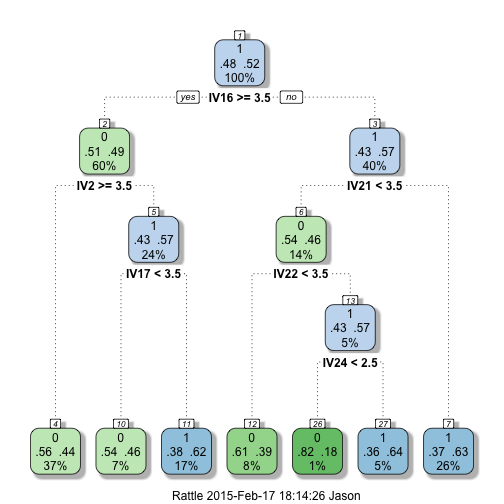

## Another Classification Tree

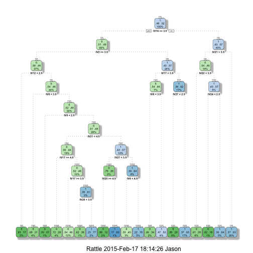

## KEY QUESTION: Model Complexity

Do we want a "large" or a "small" tree?

How complex should our classifier be?

## Logistic Regression

Logistic Regression: Estimated Coefficients

|  | Estimate | Std. Error | z value | Pr(>\|z\|) |
| --- | --- | --- | --- | --- |
| (Intercept) | -0.8 | 0.4 | -2.1 | 0.0 |
| Q16_1_Is.a.brand.that.has.been.around.for.a.long.time | 0.0 | 0.0 | 0.4 | 0.7 |
| Q16_2_Has.best.in.class.customer.service | -0.2 | 0.1 | -3.4 | 0.0 |
| Q16_3_Has.a.strong.dealer.network | 0.0 | 0.1 | 0.2 | 0.9 |
| Q16_4_Is.a.leader.in.cutting.edge.technology | -0.1 | 0.1 | -0.9 | 0.3 |
| Q16_5_Is.a.leader.in.safety | 0.1 | 0.1 | 1.1 | 0.3 |
| Q16_6_Is.known.for.its.innovative.products | -0.1 | 0.1 | -1.3 | 0.2 |
| Q16_7_Is.a.brand.for.people.who.are.serious.about.boating | -0.0 | 0.1 | -0.1 | 1.0 |
| Q16_8_Is.a.good.brand.for.people.that.are.new.to.boating | 0.1 | 0.1 | 1.8 | 0.1 |
| Q16_9_Is.a.brand.I.see.in.the.water.all.the.time | 0.1 | 0.1 | 2.1 | 0.0 |
| Q16_10_Offers.boats.that.provide.a.fast.and.powerful.boating.experience | 0.2 | 0.1 | 3.3 | 0.0 |
| Q16_11_Offers.the.best.boats.for.socializing | -0.1 | 0.1 | -2.0 | 0.0 |
| Q16_12_Offers.the.best.boats.for.water.sports..e.g...tubing..ski..wakeboard. | 0.2 | 0.1 | 3.2 | 0.0 |
| Q16_13_Offers.boats.with.superior.interior.style | -0.2 | 0.1 | -2.4 | 0.0 |
| Q16_14_Offers.boats.with.superior.exterior.style | -0.1 | 0.1 | -1.4 | 0.2 |
| Q16_15_Offers.boats.that.stand.out.from.the.crowd | 0.1 | 0.1 | 1.3 | 0.2 |
| Q16_16_Offers.boats.that.look.cool | -0.3 | 0.1 | -4.4 | 0.0 |
| Q16_17_Offers.boats.that.can.handle.rough.weather.or.choppy.water | -0.1 | 0.1 | -1.7 | 0.1 |
| Q16_18_Offers.boats.that.can.handle.frequent.and.heavy.usage | -0.1 | 0.1 | -1.0 | 0.3 |
| Q16_19_Offers.a.wide.breadth.of.product.offerings.and.accessories | 0.1 | 0.1 | 1.8 | 0.1 |
| Q16_20_Offers.boats.that.I.can.move.around.safely | 0.0 | 0.1 | 0.3 | 0.8 |
| Q16_21_Offers.boats.that.are.easy.to.maintain.and.or.repair | 0.2 | 0.1 | 2.2 | 0.0 |
| Q16_22_Offers.boats.that.are.easy.to.use | 0.1 | 0.1 | 0.9 | 0.4 |
| Q16_23_Offers.boats.that.are.easy.to.clean.up | -0.0 | 0.1 | -0.5 | 0.6 |
| Q16_24_Has.low.prices | 0.1 | 0.1 | 1.5 | 0.1 |
| Q16_25_Is.a.brand.that.gives.me.peace.of.mind | -0.1 | 0.1 | -1.1 | 0.3 |
| Q16_26_Makes.me.feel.I.made.a.smart.decision | 0.1 | 0.1 | 1.6 | 0.1 |
| Q16_27_Is.a.brand.that.impresses.others | 0.1 | 0.1 | 1.8 | 0.1 |

## Drivers Analysis

|  | CART 1 | CART 2 | Logistic Regr. |
| --- | --- | --- | --- |
| Q16_1_Is.a.brand.that.has.been.around.for.a.long.time | 0.00 | 0.01101969 | 0.09090909 |
| Q16_2_Has.best.in.class.customer.service | -1.00 | -0.8994543 | -0.7727273 |
| Q16_3_Has.a.strong.dealer.network | 0.1781076 | 0.3994461 | 0.04545455 |
| Q16_4_Is.a.leader.in.cutting.edge.technology | -0.2729842 | -0.7653571 | -0.2045455 |
| Q16_5_Is.a.leader.in.safety | 0.1948052 | 0.6577938 | 0.25 |
| Q16_6_Is.known.for.its.innovative.products | -0.1320648 | -0.1039517 | -0.2954545 |
| Q16_7_Is.a.brand.for.people.who.are.serious.about.boating | 0.00 | -0.05454026 | -0.02272727 |
| Q16_8_Is.a.good.brand.for.people.that.are.new.to.boating | 0.07231261 | 0.6581984 | 0.4090909 |
| Q16_9_Is.a.brand.I.see.in.the.water.all.the.time | 0.00 | 0.005692312 | 0.4772727 |
| Q16_10_Offers.boats.that.provide.a.fast.and.powerful.boating.experience | 0.00 | 0.4917861 | 0.75 |
| Q16_11_Offers.the.best.boats.for.socializing | -0.3209647 | -0.2301927 | -0.4545455 |
| Q16_12_Offers.the.best.boats.for.water.sports..e.g...tubing..ski..wakeboard. | 0.1404807 | 0.7367238 | 0.7272727 |
| Q16_13_Offers.boats.with.superior.interior.style | -0.1508388 | -0.3358969 | -0.5454545 |
| Q16_14_Offers.boats.with.superior.exterior.style | -0.2136343 | -0.2026567 | -0.3181818 |
| Q16_15_Offers.boats.that.stand.out.from.the.crowd | 0.134007 | 0.09610846 | 0.2954545 |
| Q16_16_Offers.boats.that.look.cool | -0.5755178 | -0.6404725 | -1.00 |
| Q16_17_Offers.boats.that.can.handle.rough.weather.or.choppy.water | -0.5041929 | -0.8468072 | -0.3863636 |
| Q16_18_Offers.boats.that.can.handle.frequent.and.heavy.usage | -0.09940166 | -0.4040648 | -0.2272727 |
| Q16_19_Offers.a.wide.breadth.of.product.offerings.and.accessories | 0.2862924 | 0.2973946 | 0.4090909 |
| Q16_20_Offers.boats.that.I.can.move.around.safely | 0.2652031 | 0.299989 | 0.06818182 |
| Q16_21_Offers.boats.that.are.easy.to.maintain.and.or.repair | 0.9530697 | 1.00 | 0.50 |
| Q16_22_Offers.boats.that.are.easy.to.use | 0.6291439 | 0.739418 | 0.2045455 |
| Q16_23_Offers.boats.that.are.easy.to.clean.up | -0.4365717 | -0.412043 | -0.1136364 |
| Q16_24_Has.low.prices | 0.5189457 | 0.3721827 | 0.3409091 |
| Q16_25_Is.a.brand.that.gives.me.peace.of.mind | -0.1706865 | -0.9380984 | -0.25 |
| Q16_26_Makes.me.feel.I.made.a.smart.decision | 0.3420844 | 0.2453395 | 0.3636364 |
| Q16_27_Is.a.brand.that.impresses.others | 0.00 | 0.7199355 | 0.4090909 |

## Hit Ratio: Validation Data

Validation Data Hit Ratios for different classifiers tested

|  | Hit Ratio |
| --- | --- |
| First CART | 60.1 |
| Second CART | 55.9 |
| Logistic Regression | 54.4 |

## Hit Ratio: Estimation Data

Estimation Data Hit Ratios for different classifiers tested

|  | Hit Ratio |
| --- | --- |
| First CART | 59.6 |
| Second CART | 64.0 |
| Logistic Regression | 59.7 |

## Fit versus Prediction

Should the performance of our model be similar in the estimation and validation data?

How about when we deploy the model?

Why should performance be different? Why should it not? What can we do about it?

## Hit Ratios: Test Data for best validation hit rate method

Test Data Hit Ratios for different classifiers tested

|  | Hit Ratio |
| --- | --- |
| First CART | 56.0 |
| Second CART | 54.3 |
| Logistic Regression | 58.5 |

## Confusion Matrix: Test Data

Confusion Matrix for test data

|  | Predicted 1 | Predicted 0 |
| --- | --- | --- |
| Actual 1 | 48.8 | 51.2 |
| Actual 0 | 61.8 | 38.2 |

## ROC Curves: Test Data

(black: CART 1; red: CART 2; blue: logistic regression):

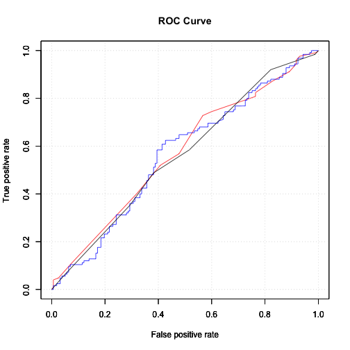

## Profit Matrix

Assumed Profits and Costs

|  | Predict 1 | Predict 0 |
| --- | --- | --- |
| Actual 1 | 100.0 | -75.0 |
| Actual 0 | -50.0 | 0.0 |

## Segment Specific Drivers Analysis

What if we do the same analysis but for each segment separately?

Does it make sense to do so? Why?

## Segment Specific Drivers Analysis

|  | Segment 1 | Segment 2 | Segment 3 | Segment 4 | Segment 5 |
| --- | --- | --- | --- | --- | --- |
| Q16_2_Has.best.in.class.customer.service | -0.4482759 | -0.7931034 | -0.1304348 | -0.1666667 | -0.80 |
| Q16_3_Has.a.strong.dealer.network | 0.1034483 | -0.1034483 | 0.1521739 | -0.04166667 | -0.20 |
| Q16_4_Is.a.leader.in.cutting.edge.technology | -0.5172414 | -0.3448276 | 0.3043478 | -0.04166667 | 0.3666667 |
| Q16_5_Is.a.leader.in.safety | 0.7241379 | 0.4137931 | -0.4782609 | -0.25 | 0.5666667 |
| Q16_6_Is.known.for.its.innovative.products | -0.3103448 | -0.1724138 | 0.06521739 | 0.25 | -0.1666667 |
| Q16_7_Is.a.brand.for.people.who.are.serious.about.boating | -0.06896552 | 0.5172414 | -0.04347826 | -0.25 | -0.40 |
| Q16_8_Is.a.good.brand.for.people.that.are.new.to.boating | 0.137931 | 0.137931 | 0.173913 | 0.2916667 | 0.8666667 |
| Q16_9_Is.a.brand.I.see.in.the.water.all.the.time | 0.4827586 | 0.1034483 | 0.4130435 | 0.5833333 | 0.1333333 |
| Q16_10_Offers.boats.that.provide.a.fast.and.powerful.boating.experience | 0.2068966 | 0.8965517 | 0.06521739 | -0.04166667 | 0.70 |
| Q16_11_Offers.the.best.boats.for.socializing | -0.2758621 | -0.4482759 | 0.3478261 | -0.5833333 | 0.1666667 |
| Q16_12_Offers.the.best.boats.for.water.sports..e.g...tubing..ski..wakeboard. | 0.5517241 | 0.5862069 | 1.00 | 0.1666667 | -0.2666667 |
| Q16_13_Offers.boats.with.superior.interior.style | -0.137931 | -0.3793103 | -0.4565217 | 0.00 | -0.03333333 |
| Q16_14_Offers.boats.with.superior.exterior.style | -0.3448276 | -0.6206897 | 0.1521739 | -0.08333333 | -0.40 |
| Q16_15_Offers.boats.that.stand.out.from.the.crowd | 0.5172414 | -0.137931 | 0.06521739 | 0.25 | 0.40 |
| Q16_16_Offers.boats.that.look.cool | -0.3793103 | -0.6206897 | -0.2391304 | -0.4583333 | -0.6666667 |
| Q16_17_Offers.boats.that.can.handle.rough.weather.or.choppy.water | 0.00 | -0.2068966 | -0.5434783 | -0.4166667 | 0.03333333 |
| Q16_18_Offers.boats.that.can.handle.frequent.and.heavy.usage | -0.4482759 | 0.2068966 | -0.3695652 | -0.2916667 | -0.30 |
| Q16_19_Offers.a.wide.breadth.of.product.offerings.and.accessories | 0.137931 | 0.4137931 | -0.02173913 | 1.00 | 0.06666667 |
| Q16_20_Offers.boats.that.I.can.move.around.safely | 0.00 | -0.1724138 | 0.1304348 | 0.04166667 | -0.10 |
| Q16_21_Offers.boats.that.are.easy.to.maintain.and.or.repair | 0.00 | 1.00 | -0.04347826 | 0.4166667 | 0.60 |
| Q16_22_Offers.boats.that.are.easy.to.use | -0.2068966 | -0.06896552 | 0.2826087 | 0.9583333 | -0.3333333 |
| Q16_23_Offers.boats.that.are.easy.to.clean.up | -0.137931 | 0.1724138 | 0.06521739 | -0.7916667 | 0.10 |
| Q16_24_Has.low.prices | 0.3103448 | 0.8275862 | -0.3478261 | 0.125 | 0.6333333 |
| Q16_25_Is.a.brand.that.gives.me.peace.of.mind | 0.2068966 | -0.8275862 | -0.2173913 | -0.8333333 | 1.00 |
| Q16_26_Makes.me.feel.I.made.a.smart.decision | 0.6551724 | 0.3448276 | -0.1304348 | 0.6666667 | 0.00 |
| Q16_27_Is.a.brand.that.impresses.others | 1.00 | 0.3448276 | -0.02173913 | 0.3333333 | 0.6666667 |

## Iterative Data Analytics Processes

Does segment specific analysis help for our business decisions?

Which solution should we use?

Should we explore a different solution?

Should we re-start from data collection, factor analysis, segmentation, or classification and drivers' analysis?

How can the company use the final solution?

## Next Class: Wrap Up